# Multi-site hierarchical PE modelling

Chris Terry

2026-06-10

```r
library(cmdstanr)
library(posterior)
library(statcomp)
library(tidyverse)
library(cowplot)

source("R/pe_data_generation.R")
source("R/pe_model_postprocess.R")
source("R/pe_prior_calibration.R")

multi_site_model <- cmdstan_model("stan/core_03_multisite_linear_pe_trend_Optimised.stan")
```

# Introduction

This document demonstrates the ability for the heierarchical (multi-site) regression model to identify trends from short simulated data.

Without known values, it isn’t really meaningful to conduct a formal power analysis. To demonstrate the abiltiy to gain increasing information from more sites, I fit the model to short (52 years = 50 motifs) data from increasing numbers of sites.

Simulated data is generated from the same Ricker based model, with two sources of noise - global and site-specific.

# Data

## Data bundling.

For the STAN function data needs to be in list form:

- N = nrow(event_data),
- K = length(motif_labels_3),
- S = max(site_index),
- G = max(time_index),
- y = as.integer(event_data$motif_id),
- site = site_index,
- time_id = time_index,
- time_scaled = event_data$time_scaled,
- time_grid_scaled = time_lookup$time_scaled,
- prior_only = as.integer(prior_only),
- slope_prior_sd = slope_prior_sd,
- sigma_site_scale = sigma_site_scale,
- sigma_period_scale = sigma_period_scale

```r
make_multisite_linear_pe_trend_bundle <- function(simulated_data_matrix,
                                                  m = 3, #  motif length
                                                  site_ids = NULL,
                                                  prior_only = 0,
                                                  slope_prior_sd = 0.5,
                                                  sigma_site_scale = 0.35,
                                                  sigma_period_scale = 0.15) {

  abundance <- simulated_data_matrix
  if (is.null(colnames(abundance))) {colnames(abundance) <- paste0("site_", seq_len(ncol(abundance)))}
  if (is.null(site_ids)) {site_ids <- seq_len(ncol(abundance))}
  if (any(site_ids < 1 | site_ids > ncol(abundance))) {
    stop("site_ids must index columns of the abundance matrix.", call. = FALSE)}

  ### Calculate Motifs

  k <- as.integer(factorial(m))
  n_year <- nrow(abundance)
  center_time <- seq.int(2L, n_year - 1L) # center time of motifs
  x_range <- range(center_time, na.rm = TRUE)
  time_grid_scaled <-(center_time - mean(x_range)) / diff(x_range)

  rows <- vector("list", length(site_ids))

  event_data <- map_df(seq_along(site_ids),function(i){
    site_col <- site_ids[i]
    motif_id <- statcomp::ordinal_pattern_time_series(abundance[, site_col], m) + 1L
    motif_id <- motif_id[seq_len(length(center_time))]

    if (any(is.na(motif_id))) {keep <- !is.na(motif_id)} else {keep <- rep(TRUE, length(motif_id))}

    data.frame(site_id = i,
               site_column = site_col,
               site_name = colnames(abundance)[site_col],
               center_time = center_time[keep],
               time_id = seq_along(center_time)[keep],
               time_scaled = time_grid_scaled[keep],
               motif_id = as.integer(motif_id[keep]))
  })

  row.names(event_data) <- NULL

  ##   Build List
  stan_data <- list(N = nrow(event_data),
                    K = k,
                    S = length(site_ids),
                    G = length(time_grid_scaled),
                    y = as.integer(event_data$motif_id),
                    site = as.integer(event_data$site_id),
                    time_id = as.integer(event_data$time_id),
                    time_scaled = as.numeric(event_data$time_scaled),
                    time_grid_scaled = as.numeric(time_grid_scaled),
                    #Prior Flag
                    prior_only = as.integer(prior_only),
                    ## Changeable Priors
                    slope_prior_sd = slope_prior_sd,
                    sigma_site_scale = sigma_site_scale,
                    sigma_period_scale = sigma_period_scale)

  ## Checkers
  stopifnot( length(stan_data$time_scaled) == stan_data$N,
             length(stan_data$time_grid_scaled) == stan_data$G,
             length(stan_data$y) == stan_data$N,
             length(stan_data$site) == stan_data$N,
             length(stan_data$time_id) == stan_data$N)

  return(stan_data)
}
```

# Single Example

### Simulating data and formatting

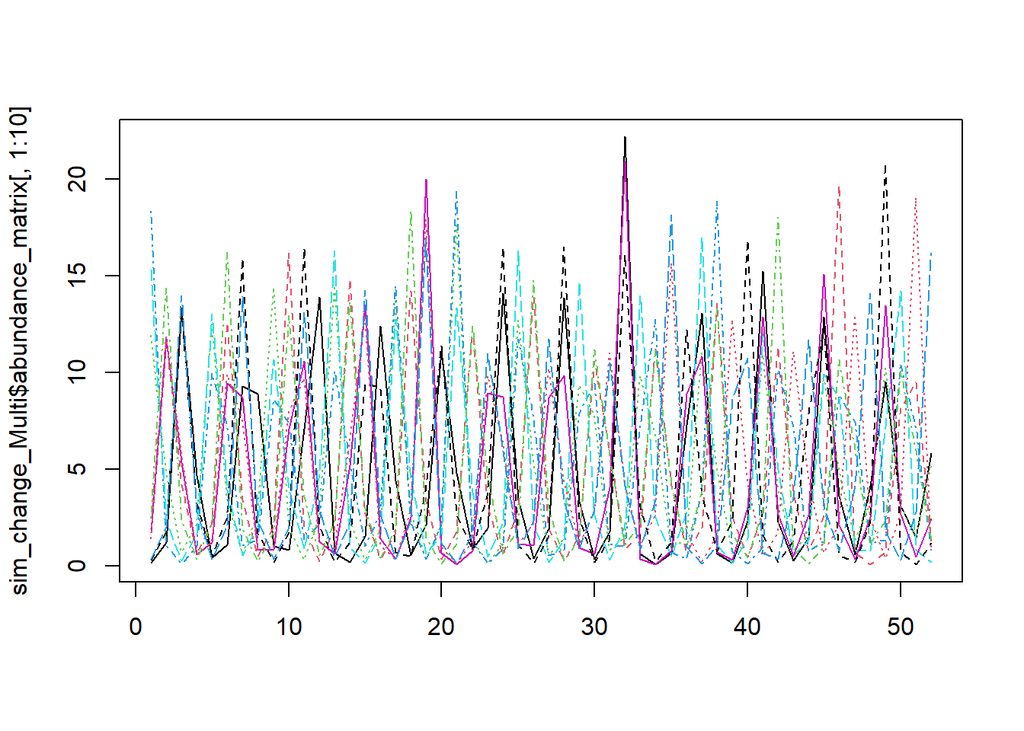

```r
sim_change_Multi<- simulate_feedback_sites(n_site = 100,n_year = 52,
                                           delayed_feedback = -1.1,
                                           rho_spatial = 0.25,
                                           sd_start = 0.1, sd_end = 0.2)

matplot(sim_change_Multi$abundance_matrix[,1:10], type='l')
```

```r
multi_site_bundle <- make_multisite_linear_pe_trend_bundle(simulated_data_matrix =  sim_change_Multi$abundance_matrix,
                                                           slope_prior_sd = 0.5,
                                                           sigma_site_scale = 0.35,
                                                           sigma_period_scale = 0.15)
```

## Fitting

```r
multi_site_model_fit <- multi_site_model$sample(data = multi_site_bundle,
  chains = 4,
  parallel_chains = 4,
  iter_warmup = 1000,
  iter_sampling = 1000,
  adapt_delta = 0.95,
  max_treedepth = 12,
  refresh = 100)

vars_keep <- c("pe_slope", "pe_intercept","alpha_nsb",
               "beta_time", "sigma_site", "sigma_period")

multi_site_summary <- multi_site_model_fit$summary(vars_keep)
multi_site_pe_time_summary <- multi_site_model_fit$summary(c("pe_population_time","pe_period_time"))

write_csv(multi_site_summary,"model fits/multi_site_summary.csv")
write_csv(multi_site_pe_time_summary, "model fits/multi_site_pe_time_summary.csv")

multi_site_metadata <- list(  n_site = multi_site_bundle$S,
                              n_time = multi_site_bundle$G,
                              n_events = multi_site_bundle$N,
                              time_grid_scaled = multi_site_bundle$time_grid_scaled,
                              slope_prior_sd = multi_site_bundle$slope_prior_sd,
                              sigma_site_scale = multi_site_bundle$sigma_site_scale,
                              sigma_period_scale = multi_site_bundle$sigma_period_scale
)

saveRDS(multi_site_metadata,"model fits/multi_site_metadata.rds")
```

```r
multi_site_summary<- read_csv("model fits/multi_site_summary.csv")
multi_site_pe_time_summary<- read_csv("model fits/multi_site_pe_time_summary.csv")
multi_site_summary
```

```
## # A tibble: 21 × 10
##    variable         mean  median      sd     mad       q5     q95  rhat ess_bulk
##    <chr>           <dbl>   <dbl>   <dbl>   <dbl>    <dbl>   <dbl> <dbl>    <dbl>
##  1 pe_slope       0.0419  0.0421 0.0127  0.0128   0.0206   0.0621 1.00     5140.
##  2 pe_intercept   0.943   0.943  0.00341 0.00341  0.937    0.949  1.00     5839.
##  3 alpha_nsb      3.08    2.61   2.03    1.70     0.746    6.95   1.00     7617.
##  4 beta_time[1]  -0.0582 -0.0599 0.123   0.119   -0.262    0.142  1.00     4688.
##  5 beta_time[2]   0.846   0.849  0.163   0.160    0.569    1.11   1.00     5257.
##  6 beta_time[3]  -0.594  -0.595  0.134   0.132   -0.813   -0.370  1.000    5126.
##  7 beta_time[4]  -0.601  -0.603  0.144   0.143   -0.837   -0.363  1.00     5195.
##  8 beta_time[5]   0.513   0.511  0.162   0.161    0.245    0.777  1.00     5716.
##  9 beta_time[6]  -0.106  -0.105  0.115   0.114   -0.296    0.0813 1.00     4968.
## 10 sigma_site[1]  0.0271  0.0233 0.0205  0.0202   0.00208  0.0654 1.00     2622.
## # ℹ 11 more rows
## # ℹ 1 more variable: ess_tail <dbl>
```

```r
multi_site_pe_time_summary
```

```
## # A tibble: 100 × 10
##    variable      mean median      sd     mad    q5   q95  rhat ess_bulk ess_tail
##    <chr>        <dbl>  <dbl>   <dbl>   <dbl> <dbl> <dbl> <dbl>    <dbl>    <dbl>
##  1 pe_populati… 0.918  0.918 0.00713 0.00689 0.906 0.930  1.00    5782.    3401.
##  2 pe_populati… 0.920  0.920 0.00695 0.00669 0.908 0.931  1.00    5805.    3371.
##  3 pe_populati… 0.921  0.921 0.00677 0.00655 0.909 0.932  1.00    5836.    3402.
##  4 pe_populati… 0.922  0.922 0.00659 0.00638 0.911 0.933  1.00    5862.    3367.
##  5 pe_populati… 0.923  0.924 0.00641 0.00620 0.913 0.934  1.00    5891.    3395.
##  6 pe_populati… 0.925  0.925 0.00622 0.00598 0.914 0.935  1.00    5916.    3256.
##  7 pe_populati… 0.926  0.926 0.00604 0.00582 0.916 0.936  1.00    5934.    3281.
##  8 pe_populati… 0.927  0.927 0.00586 0.00565 0.917 0.936  1.00    5972.    3332.
##  9 pe_populati… 0.928  0.928 0.00568 0.00549 0.919 0.937  1.00    5995.    3328.
## 10 pe_populati… 0.929  0.930 0.00549 0.00532 0.920 0.938  1.00    6032.    3308.
## # ℹ 90 more rows
```

## Compare fitted PE trend to long-series truth

These blue reference values are the long fixed-noise PE values from document 2, evaluated across the same simulated noise gradient from `sd = 0.1` to `sd = 0.2`.

Line is the underlying population effect

Dots include the period random effect.

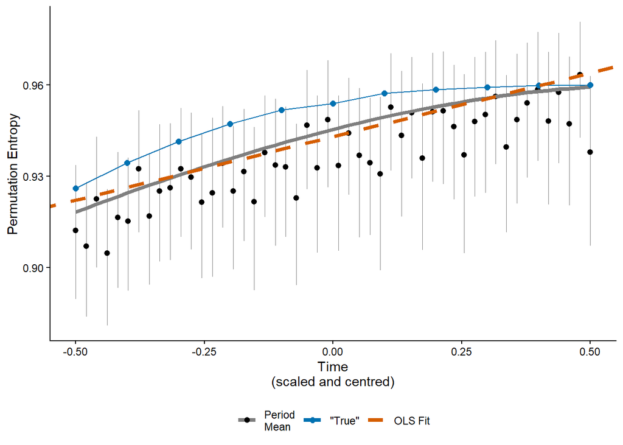

```r
## 'True' PE values from previous script:
PE_TRUE_MULTI <- data.frame(Scaled_time = seq(-0.5, 0.5, length.out = 11),
                            TruePE = c(0.9259421, 0.9343271, 0.9414366, 0.9472344, 0.9517834,
                                       0.9538866, 0.9571993, 0.9585305, 0.9591965, 0.9598608,0.9600080))

pe_population_time_df <- multi_site_pe_time_summary %>%
  filter(  str_starts(variable,'pe_population_time')) %>%
  mutate(time_id = parse_number(variable),
         time_scaled = multi_site_bundle$time_grid_scaled[time_id])

pe_period_time_df <- multi_site_pe_time_summary %>%
  filter(  str_starts(variable,'pe_period_time')) %>%
  mutate(time_id = parse_number(variable),
         time_scaled = multi_site_bundle$time_grid_scaled[time_id])


OLS_Fitted_PE_SLOPE <- filter(multi_site_summary, variable=='pe_slope')$mean
OLS_Fitted_PE_INTERCEPT <- filter(multi_site_summary, variable=='pe_intercept')$mean


ggplot(pe_period_time_df, aes(x = time_scaled, y = mean)) +
 geom_errorbar( aes(  ymin = q5,  ymax = q95,
    colour = "Period\nMean"),width = 0, linewidth = 0.2, alpha = 0.5) +
  geom_point( aes(colour = "Period\nMean"),size = 1.8) +
  geom_line(data = PE_TRUE_MULTI,
            aes(x = Scaled_time, y = TruePE, colour = '"True"')) +
  geom_line(data = pe_population_time_df,
            aes(colour = "Population\nMean"),
            linewidth = 1.5) +
  geom_point(data = PE_TRUE_MULTI,
             aes(x = Scaled_time, y = TruePE, colour = '"True"'), size = 2) +
  geom_abline(data = data.frame(slope = OLS_Fitted_PE_SLOPE,
                                intercept = OLS_Fitted_PE_INTERCEPT),
              aes( slope = slope, intercept = intercept,colour = "OLS Fit"),
              linetype= 'dashed', linewidth = 1.5,
              key_glyph = "path")+
  theme_classic() +
  theme( legend.position = 'bottom')+
  scale_colour_manual(  breaks = c( "Period\nMean",
                                    "Underlying\nPopulation\nMean",
                                    '"True"',
                                    "OLS Fit"),
                        values = c( "Period\nMean"= "black",
                                    "Underlying\nPopulation\nMean" = "#009E73",
                                    '"True"'= "#0072B2",
                                    "OLS Fit"= "#D55E00"
                        ),name = NULL) +
  guides(colour = guide_legend( override.aes = list(linewidth = 1.5) ))+
  xlab("Time\n(scaled and centred)") +
  ylab("Permutation Entropy") ->
  MultiSite_PE_ThroughTime_Trial

MultiSite_PE_ThroughTime_Trial
```

# Different Numbers of sites.

```r
n_site_grid <- c(1,seq(from=5,to=65, by 5))

NSiteTest_df <- map_df(n_site_grid, function(n_site) {
  ## Simulate raw data
  data_x <-   simulate_feedback_sites(n_site = n_site,
                                      n_year = 52,
                                      delayed_feedback = -1.1,
                                      rho_spatial = 0.25,
                                      sd_start = 0.1, sd_end = 0.2)
  ## Bundle Data
  multi_site_bundle <- make_multisite_linear_pe_trend_bundle(simulated_data_matrix = data_x$abundance_matrix,
                                                             slope_prior_sd = 0.5,
                                                             sigma_site_scale = 0.35,
                                                             sigma_period_scale = 0.15)
  ## Fit Model
  multi_site_model_fit <- multi_site_model$sample(data = multi_site_bundle,
                                                  chains = 4, parallel_chains = 4,
                                                  iter_warmup = 500,iter_sampling = 800,
                                                  refresh = 100)
  ## Prep Posterior
  multi_site_summary <- multi_site_model_fit$summary(c(  "pe_slope",  "pe_intercept",
                                                         "pe_population_time","pe_period_time",
                                                         "alpha_nsb", "beta_time",
                                                         "sigma_site","sigma_period"))
  ## Label and return
  multi_site_summary$n_site = n_site
  return(multi_site_summary)
})

write_csv('model fits/N_site_Test_df2.csv')
```

## Plotting Fitted through time

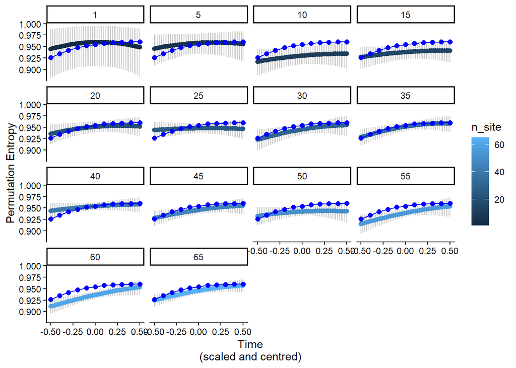

```r
 read_csv( 'model fits/N_site_Test_df2.csv' ) %>%
  filter(  str_starts(variable,'pe_population_time')) %>%
  mutate(time_id = parse_number(variable),
         time_scaled = multi_site_bundle$time_grid_scaled[time_id]) %>%
ggplot(aes(x = time_scaled, y = mean)) +
  geom_errorbar(aes(ymin = q5, ymax = q95), width = 0, col = "grey80") +
  geom_point(size = 1.8, aes(col = n_site )) +
  geom_line(data = PE_TRUE_MULTI,
            aes(x = Scaled_time, y = TruePE),
            col = "blue") +
  geom_point(data = PE_TRUE_MULTI,
             aes(x = Scaled_time, y = TruePE),
             col = "blue", size = 2) +
  theme_classic() +
  xlab("Time\n(scaled and centred)") +
  ylab("Permutation Entropy") +
   facet_wrap(~n_site)
```

## Plotting slope fits

```r
## 'True' Slope
True_slope = lm(data = PE_TRUE_MULTI, TruePE~Scaled_time)
True_slope$coefficients[2]
```

```
## Scaled_time
##  0.03215928
```

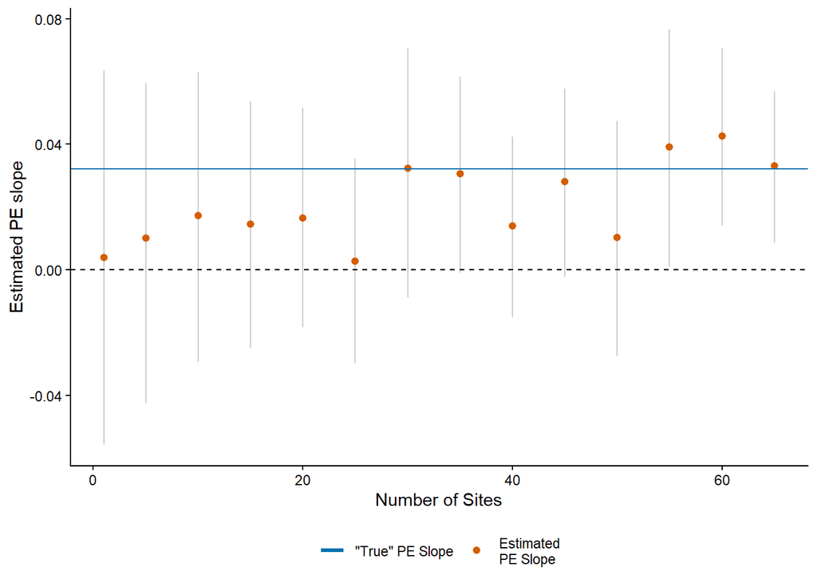

```r
read_csv('model fits/N_site_Test_df2.csv' )%>%
  filter(  str_starts(variable,'pe_slope')) %>%
  ggplot( aes( x=n_site))+
  geom_errorbar(aes(ymin = q5, ymax = q95), width = 0, col = "grey80") +
  geom_point( aes(y = mean,  colour = "Estimated\nPE Slope"),    size = 1.8)+
  geom_hline(   aes(yintercept = True_slope$coefficients[2],colour = '"True" PE Slope'),
                key_glyph = "path")+
  geom_hline( yintercept = 0, linetype = 'dashed')+
  theme_classic()+
  xlab('Number of Sites')+
  scale_colour_manual( values = c("Estimated\nPE Slope" = "#D55E00",
                                  '"True" PE Slope'= "#0072B2"),name = NULL) +
  theme( legend.position = 'bottom')+
  guides(colour = guide_legend( override.aes = list( linewidth = 1.2)) ) +
  ylab( 'Estimated PE slope')-> NSites_vs_PESlope_Plot
NSites_vs_PESlope_Plot
```

# Plotting

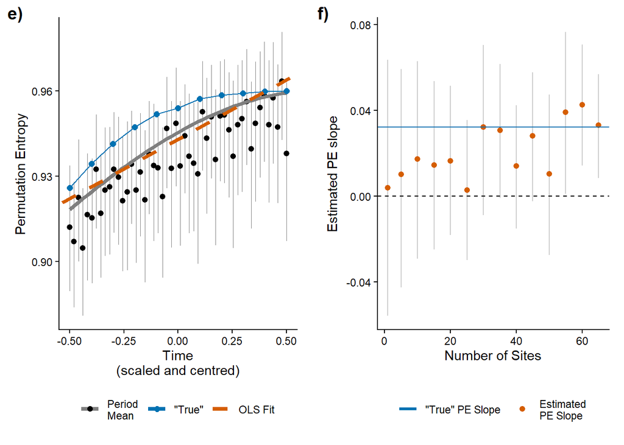

```r
demo3plot <- plot_grid(MultiSite_PE_ThroughTime_Trial,
                       NSites_vs_PESlope_Plot, align = 'h',scale = 0.95,
                       labels = c( 'e)','f)'))

demo3plot
```

# Generating Combined Figure 2

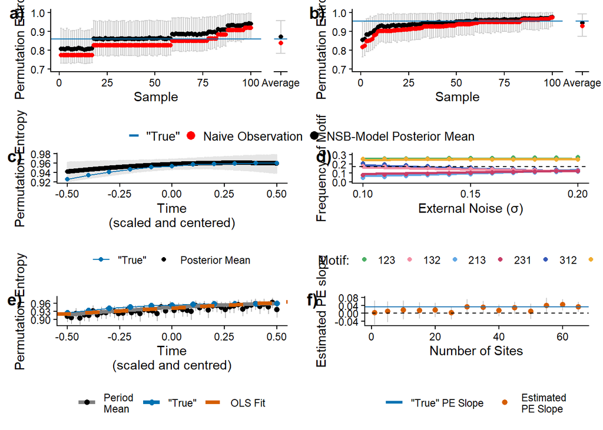

```r
demo1plot <- readRDS("MS_figs/ggplot objects/demo1plot.rds")
demo2plot <- readRDS("MS_figs/ggplot objects/demo2plot.rds")


plot_grid( demo1plot,
           demo2plot,
           demo3plot, ncol = 1)
```

```r
ggsave( filename = 'MS_Figs/Figure2_CombindedDemos.png', height = 10, width = 9)
```